# 181058_DSLab_MID

> Task 01

Create a Vector and save 6 values 1 ,2, 3,4,5,6 your id digits, Assign names to each instance and display length and type of vector.

```r
ID <- c(1,8,1,0,5,8)
names(ID) <- c("one","eight","one", "zero", "five","eight")
# Can also do it like
# id <- c("One"=1,"Eight"=8,"One"=1, "Zero"=0, "Five"=5,"Eight"=8)
print(ID)
```

```
##   one eight   one  zero  five eight
##     1     8     1     0     5     8
```

```r
paste("LENGTH -> ", length(ID)) #alternative for concatenating
```

```
## [1] "LENGTH ->  6"
```

```r
paste("Type -> ", typeof(ID))
```

```
## [1] "Type ->  double"
```

> Task 02

Create a matrix “YourName” and store 9 values row wise with 3 rows and name the row and column names. Multiply Complete Matrix with 100 and Display the output.

```r
HamzaAli <- matrix(1:9, nrow = 3, byrow=TRUE)
rownames(HamzaAli) <- c("R1","R2","R3")
colnames(HamzaAli) <- c("C1","C2","C3")
new_mat <- HamzaAli * 100
print(HamzaAli)
```

```
##    C1 C2 C3
## R1  1  2  3
## R2  4  5  6
## R3  7  8  9
```

```r
print(new_mat)
```

```
##     C1  C2  C3
## R1 100 200 300
## R2 400 500 600
## R3 700 800 900
```

> Task 03

Using Provided Dataset

```r
df <- read.csv("DataSet_MidExam_C.csv")
print("STRUCTURE")
```

```
## [1] "STRUCTURE"
```

```r
print(str(df))
```

```
## 'data.frame':    1216 obs. of  7 variables:
##  $ Country...territory       : Factor w/ 31 levels "Aruba","Barbados",..: 1 1 1 1 1 1 1 1 2 2 ...
##  $ Measure.Names             : Factor w/ 2 levels "Confirmed","Suspected": 2 1 2 1 2 1 2 1 2 1 ...
##  $ Report.Epi.Week           : int  1 1 2 2 3 3 4 4 1 1 ...
##  $ Year.of.Date              : int  2016 2016 2016 2016 2016 2016 2016 2016 2016 2016 ...
##  $ Measure.Values            : Factor w/ 113 levels "0","1","1,046",..: 1 1 1 1 1 1 1 1 1 56 ...
##  $ Laboratory.confirmed.cases: int  0 0 0 0 0 0 0 0 3 3 ...
##  $ Suspected.cases           : Factor w/ 88 levels "0","1","1,046",..: 1 1 1 1 1 1 1 1 1 1 ...
## NULL
```

```r
print("SUMMARY")
```

```
## [1] "SUMMARY"
```

```r
print(summary(df))
```

```
##                        Country...territory   Measure.Names Report.Epi.Week
##  Barbados                        : 44      Confirmed:608   Min.   : 1.0
##  Nicaragua                       : 44      Suspected:608   1st Qu.: 5.0
##  United States Virgin Islands    : 44                      Median :43.0
##  Costa Rica                      : 42                      Mean   :31.8
##  Saint Vincent and the Grenadines: 42                      3rd Qu.:48.0
##  Sint Maarten                    : 42                      Max.   :52.0
##  (Other)                         :958                      NA's   :3
##   Year.of.Date  Measure.Values Laboratory.confirmed.cases Suspected.cases
##  Min.   :2015   0      :1022   Min.   :  0.000            0      :1032
##  1st Qu.:2015   1      :  17   1st Qu.:  0.000            3      :   6
##  Median :2015   4      :  13   Median :  0.000            115    :   4
##  Mean   :2015   2      :  12   Mean   :  4.689            2      :   4
##  3rd Qu.:2016   3      :   8   3rd Qu.:  0.000            59     :   4
##  Max.   :2016   10     :   4   Max.   :526.000            1      :   2
##                 (Other): 140                              (Other): 164
```

#### Str vs Summary

According to the Output of Str and Summary,

1. Str provides the following:
- The total number of rows and columns, i.e. 1216 rows(objects) and 7 columns(variables)
- “$” gives description of each column(their factor(unique values) and int values itselfs)
2. As for summary,
- It gives summary of head, 6 rows and others
- Each column would gives total number of distinct rows, for example, Barbados has 44 rows in Country…territory
- For Integer, it would gives out Min, max, media, median, number of NA’s and basic math functions
- In short, it would give the summary of the dataset to give bried description of the provided datasets

#### Finding the Categorical and Numerical attributes

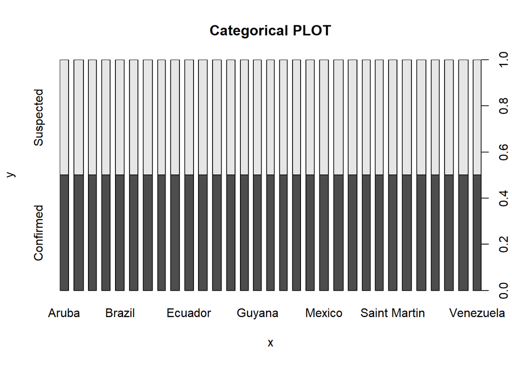

```r
df <- read.csv("DataSet_MidExam_C.csv")
plot(main = "Categorical PLOT", df$Country...territory, df$Measure.Names)
```

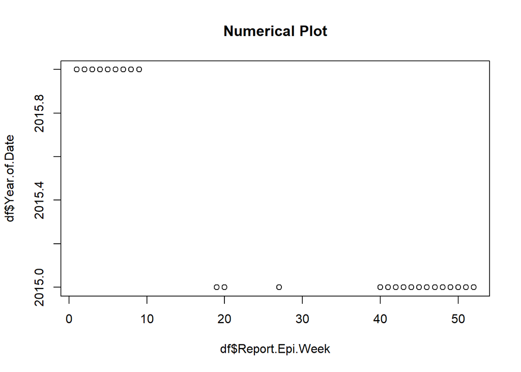

```r
plot(main = "Numerical Plot", df$Report.Epi.Week, df$Year.of.Date)
```

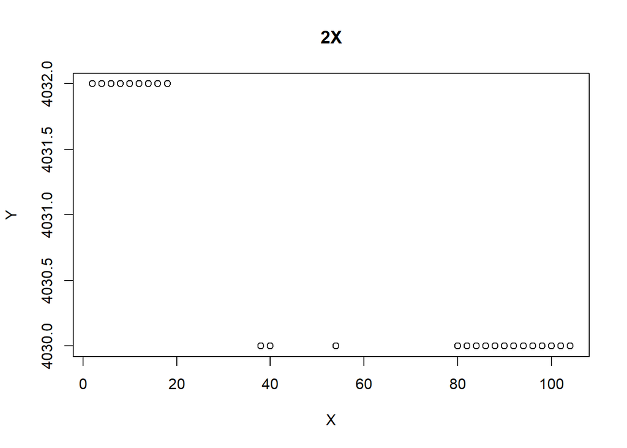

```r
plot(main = "2X", (df$Report.Epi.Week)*2, (df$Year.of.Date)*2, xlab = "X", ylab="Y")
```

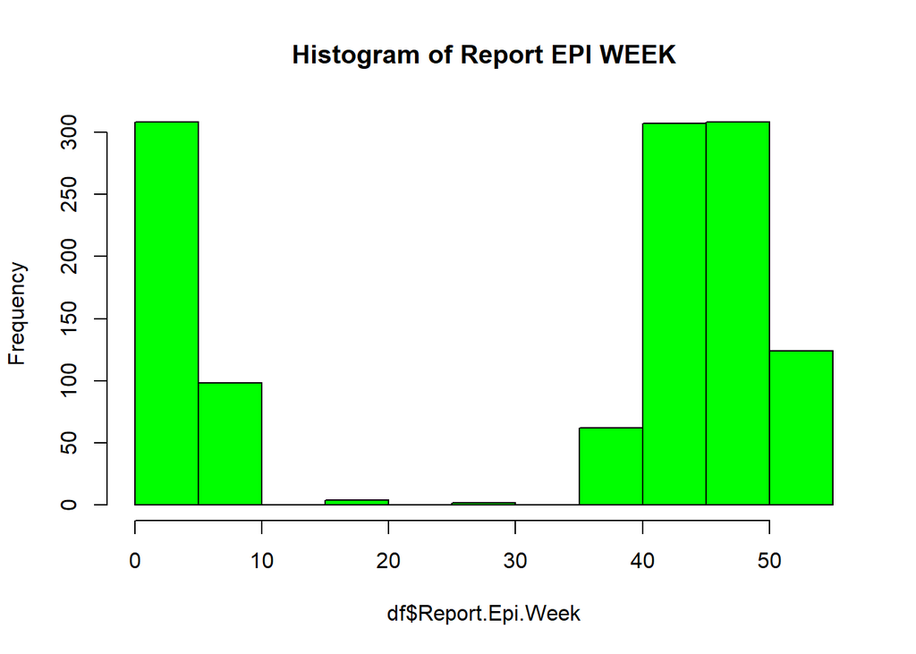

```r
hist(df$Report.Epi.Week,main = "Histogram of Report EPI WEEK", col="green", breaks = 10)
```

> Task 04

#### Top & Last5 entries of Provided Dataset

```r
print("Top 5 values")
```

```
## [1] "Top 5 values"
```

```r
print(head(df, n = 5))
```

```
##   Country...territory Measure.Names Report.Epi.Week Year.of.Date
## 1               Aruba     Suspected               1         2016
## 2               Aruba     Confirmed               1         2016
## 3               Aruba     Suspected               2         2016
## 4               Aruba     Confirmed               2         2016
## 5               Aruba     Suspected               3         2016
##   Measure.Values Laboratory.confirmed.cases Suspected.cases
## 1              0                          0               0
## 2              0                          0               0
## 3              0                          0               0
## 4              0                          0               0
## 5              0                          0               0
```

```r
print("Last 5 values")
```

```
## [1] "Last 5 values"
```

```r
print(tail(df, n = 5))
```

```
##      Country...territory Measure.Names Report.Epi.Week Year.of.Date
## 1212           Venezuela     Confirmed              50         2015
## 1213           Venezuela     Suspected              51         2015
## 1214           Venezuela     Confirmed              51         2015
## 1215           Venezuela     Suspected              52         2015
## 1216           Venezuela     Confirmed              52         2015
##      Measure.Values Laboratory.confirmed.cases Suspected.cases
## 1212              0                          0               0
## 1213              0                          0               0
## 1214              0                          0               0
## 1215              0                          0               0
## 1216              0                          0               0
```

```r
print("Summary")
```

```
## [1] "Summary"
```

```r
print(summary(df))
```

```
##                        Country...territory   Measure.Names Report.Epi.Week
##  Barbados                        : 44      Confirmed:608   Min.   : 1.0
##  Nicaragua                       : 44      Suspected:608   1st Qu.: 5.0
##  United States Virgin Islands    : 44                      Median :43.0
##  Costa Rica                      : 42                      Mean   :31.8
##  Saint Vincent and the Grenadines: 42                      3rd Qu.:48.0
##  Sint Maarten                    : 42                      Max.   :52.0
##  (Other)                         :958                      NA's   :3
##   Year.of.Date  Measure.Values Laboratory.confirmed.cases Suspected.cases
##  Min.   :2015   0      :1022   Min.   :  0.000            0      :1032
##  1st Qu.:2015   1      :  17   1st Qu.:  0.000            3      :   6
##  Median :2015   4      :  13   Median :  0.000            115    :   4
##  Mean   :2015   2      :  12   Mean   :  4.689            2      :   4
##  3rd Qu.:2016   3      :   8   3rd Qu.:  0.000            59     :   4
##  Max.   :2016   10     :   4   Max.   :526.000            1      :   2
##                 (Other): 140                              (Other): 164
```

```r
print("5 Line Summary")
```

```
## [1] "5 Line Summary"
```

```r
fivenum(df$Report.Epi.Week)
```

```
## [1]  1  5 43 48 52
```

```r
fivenum(df$Year.of.Date)
```

```
## [1] 2015 2015 2015 2016 2016
```

```r
fivenum(df$Laboratory.confirmed.cases)
```

```
## [1]   0   0   0   0 526
```

#### Difference Between Summary and 5Num summary

1. As described by its name, summary gives detailed view of the datasets, even **factors** and **string**
2. Factor only works with **numerical attributes** as it gives provides
- Minimum
- First Quartile
- Median
- Third Quartile
- Maximum

#### BoxPlot and Outliers

```r
print("BoxPlot")
```

```
## [1] "BoxPlot"
```

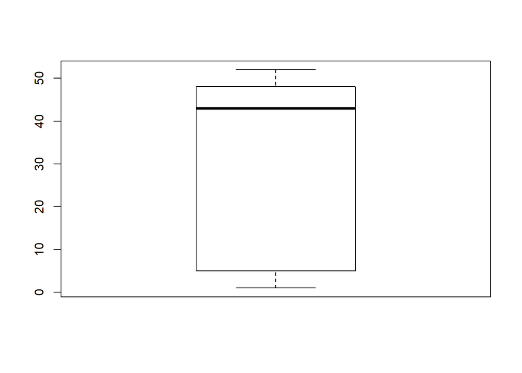

```r
boxplot(df$Report.Epi.Week)
```

According to the Boxplot, * Lowest line gives min values = 1 * 2nd lower will gives 1st quartile = 5 * bolded line is the median of column = 43 * Above that gives third quartilse = 48 * Top values give Maximun values = 52 All the values below minimum and above maximum are referred as outliers (1 > Outliers > 52)

> Task 05

#### Encode Categorical to Numerical

```r
df <- read.csv("DataSet_MidExam_C.csv")
df$Country...territory <- factor(df$Country...territory, labels= 1:31)
df$Measure.Names <- factor(df$Measure.Names, labels = c(1,2))
df$Measure.Values <- factor(df$Measure.Values, labels = 1:113)
df$Suspected.cases <- factor(df$Suspected.cases, labels = 1:88)
```

#### Missing values with mean

According to summary, we have NA at Report.Epi.Week

```r
df$Report.Epi.Week <- ifelse(is.na(df$Report.Epi.Week),
                             ave(df$Report.Epi.Week, FUN = function(x) mean(x, na.rm = TRUE)), df$Report.Epi.Week)
#print(df$Report.Epi.Week)
#for conforming
#is.na(df$Report.Epi.Week)
```

#### Split to 80/20

```r
library(caTools)
set.seed(123)
split = sample.split(df$Measure.Values, SplitRatio = 0.8)
trainingset <- subset(df, split == TRUE)
testset <- subset(df, split == FALSE)
paste("Training Set", dim(trainingset))
```

```
## [1] "Training Set 994" "Training Set 7"
```

```r
paste("Test set", dim(testset))
```

```
## [1] "Test set 222" "Test set 7"
```